# Final Project_ML_Amir Farokh

Amir Farokh

05/02/2022

### This is the Markdown file of the final project of Machine Learning course, part of Data Science Specialization. All the descriptions and expressions are included in this markdown file. Date: 5th Feb 2022, writer: Amir Farokh

#### The first step is reading the original training and test datasets of the measurements from the web source:

```r
knitr::opts_chunk$set(echo = T)
if ( ! file.exists('tds.csv') | ! file.exists('sds.csv') ) {
        download.file('https://d395qusza50orc.cloudfront.net/predmachlearn/pml-training.csv', destfile = 'tds.csv')
        download.file('https://d395qusza50orc.cloudfront.net/predmachlearn/pml-testing.csv', destfile = 'sds.csv')
}
tds1 <- read.csv('tds.csv')
sds1 <- read.csv('sds.csv')
dim(tds1) # The dimension of the original training dataset
```

```
## [1] 19622   160
```

```r
dim(sds1) # The dimension of the original test dataset
```

```
## [1]  20 160
```

##### The second step is sorting and cleansing the datasets (both training and test sets) by removing the columns having NA, nothing, or ‘#DIV/0!’. This is done by using iterative loops to remove all the corresponding columns.

```r
knitr::opts_chunk$set(echo = T)
library('caret')
tc5 <- dim(tds1)[2]
ti <- data.frame(1:(tc5-1), 1:(tc5-1), 1:(tc5-1))
ti <- t(ti)
tds2 <- tds1[,-tc5]
ck <- c()
for (i in 7:(tc5-1)) {
        ti[1, i] <- sum(is.na(tds1[,i]))
        ti[2, i] <- sum(tds1[,i] == '')
        ti[3, i] <- sum(tds1[,i] == '#DIV/0!')
        if ( ti[1,i] > 1 | ti[2,i] > 1 | ti[3,i] > 1) {
                ck <- c(ck, i)
        }
}
tds2 <- tds2[,-ck]
dim(tds2) # Dimension of the cleaned training dataset
```

```
## [1] 19622    59
```

```r
#head(tds2) # Viewing the head of the dataset:
```

##### In this step we sort the original test dataset in the same way as we did for the training dataset:

```r
knitr::opts_chunk$set(echo = T)
tc7 <- dim(sds1)[2]
sds2 <- sds1[,-tc7]
sds2 <- sds2[, -ck]
dim(sds2) # The dimension of the cleaned test dataset
```

```
## [1] 20 59
```

##### The next step is ‘Pre-processing’ which is considered as a preliminary step of classification. It was taught in week 2 of the main course:

```r
knitr::opts_chunk$set(echo = T)
# Subsetting of the cleaned dataset for only the predictors and the 'classe' outcome
tds3 <- cbind(tds2[, 7:dim(tds2)[2]], tds1$classe)
colnames(tds3)[dim(tds3)[2]] <- 'CLASS'
# Finding correlations between the existing columns
m3 <- abs(cor(tds3[, -54]))
diag(m3) <- 0
t4 <- which(m3 > 0.8, arr.ind = T)
# Listing the columns that are highly correlated to each other
print(t4)
```

```
##                  row col
## yaw_belt           4   2
## total_accel_belt   5   2
## accel_belt_y      10   2
## accel_belt_z      11   2
## accel_belt_x       9   3
## magnet_belt_x     12   3
## roll_belt          2   4
## roll_belt          2   5
## accel_belt_y      10   5
## accel_belt_z      11   5
## pitch_belt         3   9
## magnet_belt_x     12   9
## roll_belt          2  10
## total_accel_belt   5  10
## accel_belt_z      11  10
## roll_belt          2  11
## total_accel_belt   5  11
## accel_belt_y      10  11
## pitch_belt         3  12
## accel_belt_x       9  12
## gyros_arm_y       20  19
## gyros_arm_x       19  20
## magnet_arm_x      25  22
## accel_arm_x       22  25
## magnet_arm_z      27  26
## magnet_arm_y      26  27
## accel_dumbbell_x  35  29
## accel_dumbbell_z  37  30
## gyros_dumbbell_z  34  32
## gyros_forearm_z   47  32
## gyros_dumbbell_x  32  34
## gyros_forearm_z   47  34
## pitch_dumbbell    29  35
## yaw_dumbbell      30  37
## gyros_forearm_z   47  46
## gyros_dumbbell_x  32  47
## gyros_dumbbell_z  34  47
## gyros_forearm_y   46  47
```

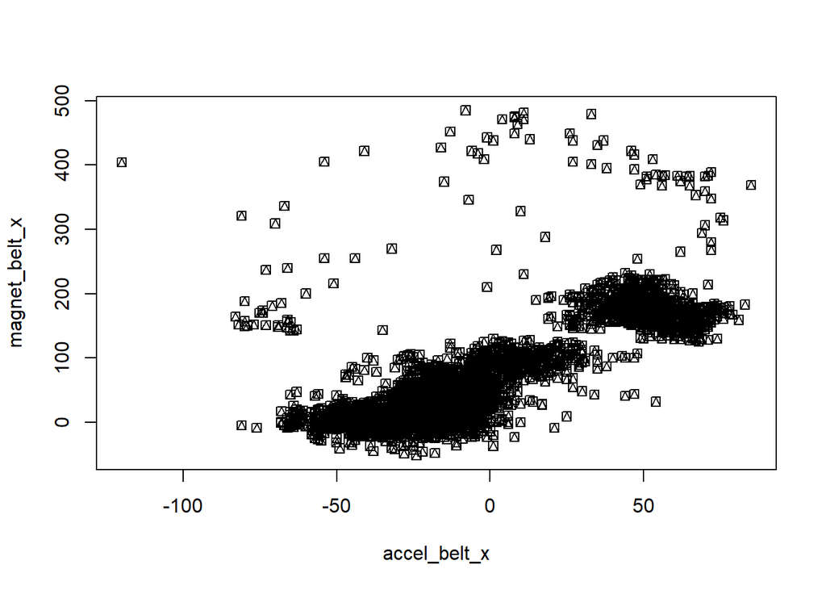

```r
# A sample plot of the two correlated columns, columns number 9 and 12
plot(tds3[,9], tds3[,12], pch = 14, xlab = colnames(tds3)[9], ylab = colnames(tds3)[12])
```

```r
tt2 <- unique(t4[,1])
tt3 <- dim.data.frame(tt2)[2]
# Listing the number of columns that are highly correlated to each other
print(tt3)
```

```
## [1] 22
```

```r
# Using 'pca' model and predicting the new dataset: tci as a substitute of the original training dataset
cp2 <- preProcess(tds3, method = 'pca', pcaComp = tt3)
tci <- predict(cp2, tds3)
dim(tci) # The dimension of the pre-processed training dataset
```

```
## [1] 19622    23
```

```r
head(tci)
```

```
##   CLASS       PC1      PC2      PC3       PC4       PC5      PC6        PC7
## 1     A -4.345108 1.477161 2.837886 0.8267079 -1.277361 1.804848 0.15315496
## 2     A -4.387404 1.485296 2.838415 0.8308328 -1.350235 1.878609 0.10955347
## 3     A -4.356336 1.503323 2.839315 0.8274958 -1.282940 1.813262 0.12579387
## 4     A -4.369928 1.496207 2.824769 0.8260587 -1.295894 1.852650 0.09846662
## 5     A -4.359088 1.554682 2.795380 0.8168495 -1.308293 1.894401 0.08549326
## 6     A -4.366141 1.525547 2.836842 0.8238480 -1.292509 1.834509 0.11673700
##         PC8       PC9      PC10     PC11       PC12     PC13     PC14      PC15
## 1 -2.831521 0.2069360 0.2228905 1.079170 -0.2341699 3.395978 1.044379 0.3590964
## 2 -2.780864 0.2423399 0.2551596 1.063585 -0.3046975 3.320160 1.103322 0.3672274
## 3 -2.808064 0.2409838 0.2446344 1.071104 -0.2946751 3.345075 1.062272 0.3720738
## 4 -2.776891 0.2629209 0.2535699 1.075905 -0.2590467 3.330434 1.092269 0.3955812
## 5 -2.784420 0.2199533 0.2761241 1.027968 -0.3135074 3.344596 1.035590 0.2817996
## 6 -2.813044 0.2428849 0.2268739 1.056428 -0.2593751 3.355209 1.071147 0.3827559
##         PC16       PC17      PC18      PC19     PC20       PC21      PC22
## 1 -0.7537670 0.07383567 0.6613328 0.3287366 1.450076 -0.7018841 0.2457228
## 2 -0.7966835 0.13249320 0.6766567 0.2880659 1.461901 -0.7006354 0.1851184
## 3 -0.7746812 0.10365126 0.6712796 0.3099980 1.453866 -0.6835297 0.2249826
## 4 -0.7962696 0.12515330 0.6389866 0.2901872 1.454275 -0.6932068 0.1842993
## 5 -0.7237507 0.14668752 0.6956181 0.2902626 1.440900 -0.7115750 0.2029736
## 6 -0.7737349 0.11016058 0.6510214 0.3096036 1.439016 -0.6902553 0.2127777
```

```r
knitr::opts_chunk$set(echo = T)
sds3 <- cbind(sds2[,7:dim(sds2)[2]], sds1$problem_id)
colnames(sds3)[dim(sds3)[2]] <- 'user_ID'
sci <- predict(cp2, sds3)
dim(sci) # The dimension of the pre-processed test dataset
```

```
## [1] 20 23
```

```r
knitr::opts_chunk$set(echo = T)
# Grouping the training dataset (tci) based on the username of the people appeared in the dataset:
n1 <- unique((tds2$user_name))
print(n1) # Viewing all the usernames
```

```
## [1] "carlitos" "pedro"    "adelmo"   "charles"  "eurico"   "jeremy"
```

```r
# Grouping in 5 groups
tc1 <- tci[which(tds2$user_name == n1[1]),]
tc2 <- tci[which(tds2$user_name == n1[2]),]
tc3 <- tci[which(tds2$user_name == n1[3]),]
tc4 <- tci[which(tds2$user_name == n1[4]),]
tc5 <- tci[which(tds2$user_name == n1[5]),]
tc6 <- tci[which(tds2$user_name == n1[6]),]
```

```r
knitr::opts_chunk$set(echo = T)

tcn1 <- createDataPartition(y = tc1$CLASS, p = 0.75, list = F)
tcw1 <- tc1[tcn1,]
tcq1 <- tc1[-tcn1,]

tcn2 <- createDataPartition(y = tc2$CLASS, p = 0.75, list = F)
tcw2 <- tc2[tcn2,]
tcq2 <- tc2[-tcn2,]

tcn3 <- createDataPartition(y = tc3$CLASS, p = 0.75, list = F)
tcw3 <- tc3[tcn3,]
tcq3 <- tc3[-tcn3,]

tcn4 <- createDataPartition(y = tc4$CLASS, p = 0.75, list = F)
tcw4 <- tc4[tcn4,]
tcq4 <- tc4[-tcn4,]

tcn5 <- createDataPartition(y = tc5$CLASS, p = 0.75, list = F)
tcw5 <- tc5[tcn5,]
tcq5 <- tc5[-tcn5,]

tcn6 <- createDataPartition(y = tc6$CLASS, p = 0.75, list = F)
tcw6 <- tc6[tcn6,]
tcq6 <- tc6[-tcn6,]

# Subsetting the new test set based on the usernames:
sr1 <- sci[which(sds1$user_name == n1[1]),]
sr2 <- sci[which(sds1$user_name == n1[2]),]
sr3 <- sci[which(sds1$user_name == n1[3]),]
sr4 <- sci[which(sds1$user_name == n1[4]),]
sr5 <- sci[which(sds1$user_name == n1[5]),]
sr6 <- sci[which(sds1$user_name == n1[6]),]
```

##### The next step or the main step is using the training models of random forest (RF), gradient boost (gbm), and C5.0 methods for the 6 training subsets; tc1 to tc6:

##### Group 1

```r
knitr::opts_chunk$set(echo = T)
#fdf_1 <- train(CLASS ~., data = tcw1, method = 'rf')  # Good
#fdg_1 <- train(CLASS ~., data = tcw1, method = 'gbm', verbose = F) # Good
## Tree-based model of classification
#fde_1 <- train(CLASS ~., data = tcw1, method = 'C5.0')

# Saving the result for the future use
#save(fdf_1, file = 'fdf_1')
#save(fdg_1, file = 'fdg_1')
#save(fde_1, file = 'fde_1')

load('fde_1')
load('fdf_1')
load('fdg_1')

# Cross validation by using test sets
sdt1_f <- predict(fdf_1, tcq1)
sdt1_g <- predict(fdg_1, tcq1)
sdt1_e <- predict(fde_1, tcq1)

# Computing the accuracy of prediction of the models (Cross validation)
sdd1_f <- (1-sum(as.character(sdt1_f) != tcq1$CLASS)/dim(tcq1)[1])*100
sdd1_g <- (1-sum(as.character(sdt1_g) != tcq1$CLASS)/dim(tcq1)[1])*100
sdd1_e <- (1-sum(as.character(sdt1_e) != tcq1$CLASS)/dim(tcq1)[1])*100
sprintf('The accuracy of the rf model for the new test set is: %2f percent', sdd1_f)
```

```
## [1] "The accuracy of the rf model for the new test set is: 99.742268 percent"
```

```r
sprintf('The accuracy of the gbm model for the new test set is: %2f percent', sdd1_g)
```

```
## [1] "The accuracy of the gbm model for the new test set is: 99.355670 percent"
```

```r
sprintf('The accuracy of the C5.0 model for the new test set is: %2f percent', sdd1_e)
```

```
## [1] "The accuracy of the C5.0 model for the new test set is: 99.742268 percent"
```

```r
# Predicting the outcome of the three models for the original test data set, and for the first username
sf1_f <- predict(fdf_1, sr1)
sf1_g <- predict(fdg_1, sr1)
sf1_e <- predict(fde_1, sr1)
```

##### Group 2

```r
knitr::opts_chunk$set(echo = T)
#fdf_2 <- train(CLASS ~., data = tcw2, method = 'rf')  # Good
#fdg_2 <- train(CLASS ~., data = tcw2, method = 'gbm', verbose = F) # Good
## Tree-based model of classification
#fde_2 <- train(CLASS ~., data = tcw2, method = 'C5.0')

# Saving the result for the future use
#save(fdf_2, file = 'fdf_2')
#save(fdg_2, file = 'fdg_2')
#save(fde_2, file = 'fde_2')

load('fde_2')
load('fdf_2')
load('fdg_2')

# Cross validation by using test sets
sdt2_f <- predict(fdf_2, tcq2)
sdt2_g <- predict(fdg_2, tcq2)
sdt2_e <- predict(fde_2, tcq2)

# Computing the accuracy of prediction of the models (Cross validation)
sdd2_f <- (1-sum(as.character(sdt2_f) != tcq2$CLASS)/dim(tcq2)[1])*100
sdd2_g <- (1-sum(as.character(sdt2_g) != tcq2$CLASS)/dim(tcq2)[1])*100
sdd2_e <- (1-sum(as.character(sdt2_e) != tcq2$CLASS)/dim(tcq2)[1])*100
sprintf('The accuracy of the rf model for the new test set is: %2f percent', sdd2_f)
```

```
## [1] "The accuracy of the rf model for the new test set is: 98.924731 percent"
```

```r
sprintf('The accuracy of the gbm model for the new test set is: %2f percent', sdd2_g)
```

```
## [1] "The accuracy of the gbm model for the new test set is: 97.849462 percent"
```

```r
sprintf('The accuracy of the C5.0 model for the new test set is: %2f percent', sdd2_e)
```

```
## [1] "The accuracy of the C5.0 model for the new test set is: 98.617512 percent"
```

```r
# Predicting the outcome based on the three models for the original test data set, and for the second username
sf2_f <- predict(fdf_2, sr2)
sf2_g <- predict(fdg_2, sr2)
sf2_e <- predict(fde_2, sr2)
```

##### Group 3

```r
knitr::opts_chunk$set(echo = T)
#fdf_3 <- train(CLASS ~., data = tcw3, method = 'rf')  # Good
#fdg_3 <- train(CLASS ~., data = tcw3, method = 'gbm', verbose = F) # Good
## Tree-based model of classification
#fde_3 <- train(CLASS ~., data = tcw3, method = 'C5.0')

# Saving the result for the future use
#save(fdf_3, file = 'fdf_3')
#save(fdg_3, file = 'fdg_3')
#save(fde_3, file = 'fde_3')

load('fde_3')
load('fdf_3')
load('fdg_3')

# Cross validation by using test sets
sdt3_f <- predict(fdf_3, tcq3)
sdt3_g <- predict(fdg_3, tcq3)
sdt3_e <- predict(fde_3, tcq3)

# Computing the accuracy of prediction of the models (Cross validation)
sdd3_f <- (1-sum(as.character(sdt3_f) != tcq3$CLASS)/dim(tcq3)[1])*100
sdd3_g <- (1-sum(as.character(sdt3_g) != tcq3$CLASS)/dim(tcq3)[1])*100
sdd3_e <- (1-sum(as.character(sdt3_e) != tcq3$CLASS)/dim(tcq3)[1])*100
sprintf('The accuracy of the rf model for the new test set is: %2f percent', sdd3_f)
```

```
## [1] "The accuracy of the rf model for the new test set is: 99.485067 percent"
```

```r
sprintf('The accuracy of the gbm model for the new test set is: %2f percent', sdd3_g)
```

```
## [1] "The accuracy of the gbm model for the new test set is: 97.219361 percent"
```

```r
sprintf('The accuracy of the C5.0 model for the new test set is: %2f percent', sdd3_e)
```

```
## [1] "The accuracy of the C5.0 model for the new test set is: 99.176107 percent"
```

```r
# Predicting the outcome based on the three models for the original test data set, and for the third username
sf3_f <- predict(fdf_3, sr3)
sf3_g <- predict(fdg_3, sr3)
sf3_e <- predict(fde_3, sr3)
```

##### Group 4

```r
knitr::opts_chunk$set(echo = T)
#fdf_4 <- train(CLASS ~., data = tcw4, method = 'rf')  # Good
#fdg_4 <- train(CLASS ~., data = tcw4, method = 'gbm', verbose = F) # Good
## Tree-based model of classification
#fde_4 <- train(CLASS ~., data = tcw4, method = 'C5.0')

# Saving the result for the future use
#save(fdf_4, file = 'fdf_4')
#save(fdg_4, file = 'fdg_4')
#save(fde_4, file = 'fde_4')

load('fde_4')
load('fdf_4')
load('fdg_4')

# Cross validation by using test sets
sdt4_f <- predict(fdf_4, tcq4)
sdt4_g <- predict(fdg_4, tcq4)
sdt4_e <- predict(fde_4, tcq4)

# Computing the accuracy of prediction of the models (Cross validation)
sdd4_f <- (1-sum(as.character(sdt4_f) != tcq4$CLASS)/dim(tcq4)[1])*100
sdd4_g <- (1-sum(as.character(sdt4_g) != tcq4$CLASS)/dim(tcq4)[1])*100
sdd4_e <- (1-sum(as.character(sdt4_e) != tcq4$CLASS)/dim(tcq4)[1])*100
sprintf('The accuracy of the rf model for the new test set is: %2f percent', sdd4_f)
```

```
## [1] "The accuracy of the rf model for the new test set is: 99.318956 percent"
```

```r
sprintf('The accuracy of the gbm model for the new test set is: %2f percent', sdd4_g)
```

```
## [1] "The accuracy of the gbm model for the new test set is: 98.978434 percent"
```

```r
sprintf('The accuracy of the C5.0 model for the new test set is: %2f percent', sdd4_e)
```

```
## [1] "The accuracy of the C5.0 model for the new test set is: 99.205448 percent"
```

```r
# Predicting the outcome based on the three models for the original test data set, and for the fourth username
sf4_f <- predict(fdf_4, sr4)
sf4_g <- predict(fdg_4, sr4)
sf4_e <- predict(fde_4, sr4)
```

##### Group 5

```r
knitr::opts_chunk$set(echo = T)
#fdf_5 <- train(CLASS ~., data = tcw5, method = 'rf')  # Good
#fdg_5 <- train(CLASS ~., data = tcw5, method = 'gbm', verbose = F) # Good
## Tree-based model of classification
#fde_5 <- train(CLASS ~., data = tcw5, method = 'C5.0')

# Saving the result for the future use
#save(fdf_5, file = 'fdf_5')
#save(fdg_5, file = 'fdg_5')
#save(fde_5, file = 'fde_5')

load('fde_5')
load('fdf_5')
load('fdg_5')

# Cross validation by using test sets
sdt5_f <- predict(fdf_5, tcq5)
sdt5_g <- predict(fdg_5, tcq5)
sdt5_e <- predict(fde_5, tcq5)

# Computing the accuracy of prediction of the models (Cross validation)
sdd5_f <- (1-sum(as.character(sdt5_f) != tcq5$CLASS)/dim(tcq5)[1])*100
sdd5_g <- (1-sum(as.character(sdt5_g) != tcq5$CLASS)/dim(tcq5)[1])*100
sdd5_e <- (1-sum(as.character(sdt5_e) != tcq5$CLASS)/dim(tcq5)[1])*100
sprintf('The accuracy of the rf model for the new test set is: %2f percent', sdd5_f)
```

```
## [1] "The accuracy of the rf model for the new test set is: 99.738903 percent"
```

```r
sprintf('The accuracy of the gbm model for the new test set is: %2f percent', sdd5_g)
```

```
## [1] "The accuracy of the gbm model for the new test set is: 99.347258 percent"
```

```r
sprintf('The accuracy of the C5.0 model for the new test set is: %2f percent', sdd5_e)
```

```
## [1] "The accuracy of the C5.0 model for the new test set is: 99.608355 percent"
```

```r
# Predicting the outcome based on the three models for the original test data set, and for the fifth username
sf5_f <- predict(fdf_5, sr5)
sf5_g <- predict(fdg_5, sr5)
sf5_e <- predict(fde_5, sr5)
```

##### Group 6

```r
knitr::opts_chunk$set(echo = T)
#fdf_6 <- train(CLASS ~., data = tcw6, method = 'rf')  # Good
#fdg_6 <- train(CLASS ~., data = tcw6, method = 'gbm', verbose = F) # Good
## Tree-based model of classification
#fde_6 <- train(CLASS ~., data = tcw6, method = 'C5.0')

# Saving the result for the future use
#save(fdf_6, file = 'fdf_6')
#save(fdg_6, file = 'fdg_6')
#save(fde_6, file = 'fde_6')

load('fde_6')
load('fdf_6')
load('fdg_6')

# Cross validation by using test sets
sdt6_f <- predict(fdf_6, tcq6)
sdt6_g <- predict(fdg_6, tcq6)
sdt6_e <- predict(fde_6, tcq6)

# Computing the accuracy of prediction of the models (Cross validation)
sdd6_f <- (1-sum(as.character(sdt6_f) != tcq6$CLASS)/dim(tcq6)[1])*100
sdd6_g <- (1-sum(as.character(sdt6_g) != tcq6$CLASS)/dim(tcq6)[1])*100
sdd6_e <- (1-sum(as.character(sdt6_e) != tcq6$CLASS)/dim(tcq6)[1])*100
sprintf('The accuracy of the rf model for the new test set is: %2f percent', sdd6_f)
```

```
## [1] "The accuracy of the rf model for the new test set is: 99.293286 percent"
```

```r
sprintf('The accuracy of the gbm model for the new test set is: %2f percent', sdd6_g)
```

```
## [1] "The accuracy of the gbm model for the new test set is: 98.233216 percent"
```

```r
sprintf('The accuracy of the C5.0 model for the new test set is: %2f percent', sdd6_e)
```

```
## [1] "The accuracy of the C5.0 model for the new test set is: 98.704358 percent"
```

```r
# Predicting the outcome based on the three models for the original test data set, and for the sixth username
sf6_f <- predict(fdf_6, sr6)
sf6_g <- predict(fdg_6, sr6)
sf6_e <- predict(fde_6, sr6)
```

##### We present the final Result for the predictions of outcome for the original test dataset (sci):

```r
knitr::opts_chunk$set(echo = T)
DF <- data.frame(userID = c(sr1$user_ID, sr2$user_ID, sr3$user_ID, sr4$user_ID, sr5$user_ID, sr6$user_ID), RF = c(sf1_f, sf2_f, sf3_f, sf4_f, sf5_f, sf6_f), GBM = c(sf1_g, sf2_g, sf3_g, sf4_g, sf5_g, sf6_g), CFive = c(sf1_e, sf2_e, sf3_e, sf4_e, sf5_e, sf6_e))
DF2 <- DF[order(DF$userID),]
sprintf('The final prediction for the 20 cases of the original test dataset is: ')
```

```
## [1] "The final prediction for the 20 cases of the original test dataset is: "
```

```r
DF2
```

```
##    userID RF GBM CFive
## 4       1  B   B     B
## 13      2  A   A     A
## 14      3  B   B     B
## 7       4  A   A     A
## 9       5  A   A     A
## 15      6  E   E     E
## 16      7  D   D     D
## 17      8  B   B     B
## 1       9  A   A     A
## 8      10  A   A     A
## 2      11  B   B     A
## 18     12  C   C     C
## 10     13  B   B     B
## 19     14  A   A     A
## 20     15  E   E     E
## 11     16  E   E     E
## 5      17  A   A     A
## 3      18  B   B     B
## 6      19  B   B     B
## 12     20  B   B     B
```

##### We cannot judge about the accuracy of the above grades (outcome) for the test dataset, as we don’t have the right answer. However, we submitted the above result as the answer of the final quiz of the course, I got 100% points. Means all the predictions have been true. We only note that for user_D number 11 (above matrix), we considered B as matter of voting 2 out of 3.

##### At last, we combine the three classifiers (rf, gbm, C5.0) for only the first username and evaluating the accuracy of prediction (Cross validation) again:

```r
knitr::opts_chunk$set(echo = T)
df1 <- data.frame(sdt1_f, sdt1_g, sdt1_e, CLASS = tcq1$CLASS)
#mf2 <- train(CLASS ~ ., data = df1, method = 'rf')
#save(mf2, file = 'mf2')
load('mf2')
pp1 <- predict(mf2, df1)
dv4 <- (1-sum(as.character(pp1) != tcq1$CLASS)/dim(tcq1)[1])*100
#mf3 <- train(CLASS ~ ., data = df1, method = 'gbm')
#save('mf3', file = 'mf3')
load('mf3')
pp2 <- predict(mf3, df1)
dv5 <- (1-sum(as.character(pp2) != tcq1$CLASS)/dim(tcq1)[1])*100
sprintf('The accuracy of prediction of rf method for the combined classifiers (three classifiers) is: %2f percent', dv4)
```

```
## [1] "The accuracy of prediction of rf method for the combined classifiers (three classifiers) is: 99.871134 percent"
```

```r
sprintf('The accuracy of prediction of gbm method for the combined classifiers (three classifiers) is: %2f percent', dv5)
```

```
## [1] "The accuracy of prediction of gbm method for the combined classifiers (three classifiers) is: 99.871134 percent"
```